# Simulation-based Inference

# Bayesian Recap

## Data Generating Process

We observe $X \sim p_0$.

$p_0$ is the *data generating process*.

How can we use $X$ to make inferences about $p_0$?

## Bayesian Approach

Assume $p_0 \in \mathcal{P} = \{p(\cdot \mid \theta) : \theta \in \Theta\}$.

The prior $p(\theta)$ describes our uncertainty before observing $x$.

After observing $X=x$, update by Bayes’ rule.

$$p(\theta \mid x)
= \frac{p(x \mid \theta)\,p(\theta)}{p(x)}
\propto p(x \mid \theta)\,p(\theta).$$

$p(\theta\mid x)$ $\propto$ $p(x\mid\theta)$ $p(\theta)$

### Conjugacy

Let $x$ count successes in $n$ independent trials with success probability $\theta$ and a $\operatorname{Beta}(a,b)$ prior.

$\displaystyle p(\theta)=\frac{\theta^{a-1}(1-\theta)^{b-1}}{\mathrm{B}(a,b)}$

$\displaystyle p(x\mid\theta)=\binom{n}{x}\theta^x(1-\theta)^{n-x}$

$\displaystyle p(\theta\mid x)=\frac{\theta^{a+x-1}(1-\theta)^{b+n-x-1}}{\mathrm{B}(a+x,b+n-x)}$

### Markov-Chain Monte Carlo

Draw $\theta' \sim q(\cdot\mid\theta)$.

Set $r=$ $p(x\mid\theta')$ $p(\theta')$ $q(\theta\mid\theta')$ $p(x\mid\theta)\,p(\theta)\,q(\theta'\mid\theta)$.

Draw $u\sim\operatorname{Uniform}(0,1)$.

If $u < \min(1,r)$, set $\theta \leftarrow \theta'$.

### Simulation-based inference

Assume we can sample from the prior and the simulator, even when the **likelihood is intractable**.

$\theta \sim p(\theta)$

$X \sim p(\cdot\mid\theta)$

we call this the simulator

# Introduction to Simulation-based Inference

## Epidemiology

What is the probability of infection after contact with an infectious person?

What is the probability of recovery in one time step?

[figure not shown]

## Let’s make a simulator

$\theta = (\theta_1, \theta_2)$  
Per time step

Transmission per infectious neighbor

*θ*<sub>1</sub> = 0.499

Recovery per infectious person

*θ*<sub>2</sub> = 0.265

Simulated states

[interactive chart not shown]

Last observation

[interactive chart not shown]

Step 8

One person per cellSusceptibleInfectiousRecovered

## Real-world observations

We observe the SIR outbreak $x^*$ simulated at $\theta\approx(0.499,0.265)$. Here are the first three of eight visits.

[interactive chart not shown]

*t* = 4

[interactive chart not shown]

*t* = 8

[interactive chart not shown]

*t* = 12

Red cells were recorded as infectious.

We want to find the posterior $p(\theta \mid x^*)$.

# Neural Methods for SBI

## Conditional density estimation

Generate $\theta \sim p(\theta)$, then $x \sim p(x \mid \theta)$.

Parameterize the conditional density $q$ with a neural network $q_\phi$.

$\begin{gathered} (x^{(1)},\theta^{(1)})\\[0.3em] \vdots\\[0.3em] (x^{(n)},\theta^{(n)}) \end{gathered}$

Neural CDE

$q_\phi(x\mid\theta)$

$q_\phi(x\mid\theta) \approx p(x\mid\theta)$ $\leftarrow$ call this **Neural Likelihood Estimation (NLE)**

Train by minimizing $\mathcal L_{\mathrm{NLE}}(\phi)=\mathbb E_{(x,\theta)\sim p(x,\theta)}\!\left[-\log q_\phi(x\mid\theta)\right]$

Run MCMC with target proportional to $q_\phi(x^*\mid\theta)\,p(\theta)$.

## Conditional density estimation

Generate $\theta \sim p(\theta)$, then $x \sim p(x \mid \theta)$.

Parameterize the conditional density $q$ with a neural network $q_\phi$.

$\begin{gathered} (x^{(1)},\theta^{(1)})\\[0.3em] \vdots\\[0.3em] (x^{(n)},\theta^{(n)}) \end{gathered}$

Neural CDE

$q_\phi(x\mid\theta)$ $q_\phi(\theta\mid x)$

$q_\phi(x\mid\theta) \approx p(x\mid\theta)$ $q_\phi(\theta\mid x) \approx p(\theta\mid x)$ $\leftarrow$ call this **Neural Likelihood Estimation (NLE)** **Neural Posterior Estimation (NPE)**

Train by minimizing $\mathcal L_{\mathrm{NLE}}(\phi)=\mathbb E_{(x,\theta)\sim p(x,\theta)}\!\left[-\log q_\phi(x\mid\theta)\right]$ $\mathcal L_{\mathrm{NPE}}(\phi)=\mathbb E_{(x,\theta)\sim p(x,\theta)}\!\left[-\log q_\phi(\theta\mid x)\right]$

Use $q_\phi$ as the approximated posterior.

## Transport maps

For every $x$, draw $\eta \sim \mathcal N(0,I)$ and transform it into

$$\theta = T_\phi(\eta; x) \sim q_\phi(\theta \mid x) \approx p(\theta \mid x).$$

The heatmap uses a second outbreak with an eight-step delay before infectiousness.

[figure not shown]

## Normalizing flows

For fixed $x$, the inverse and Jacobian determinant must be tractable since

$q_\phi(\theta \mid x) = \mathcal N\!\bigl($$T_\phi^{-1}(\theta; x)$$\mid 0,I\bigr)$ $\displaystyle\left|\det \frac{\partial T_\phi^{-1}(\theta; x)}{\partial \theta}\right|$$.$

[Dax et al. (2023), Fig. 1, NPE panel](https://arxiv.org/pdf/2305.17161#page=2)

**Normalizing flows put a lot of constraints on the architecture of the network.**

Can we develop more flexible architectures for density estimation?

# Research Direction I: Generative Modeling for SBI

## Flow matching

Learn a vector field $v_{t,x}$ whose flow takes samples from $\mathcal N(0,I)$ to the learned posterior $q_\phi(\theta\mid x)$ by minimizing

$$\mathcal L_{\mathrm{FM}}(v)
=\mathbb E_{\theta,x,\eta,t}\!\left[\left\|v_{t,x}(\theta_t)-(\theta-\eta)\right\|^2\right].$$

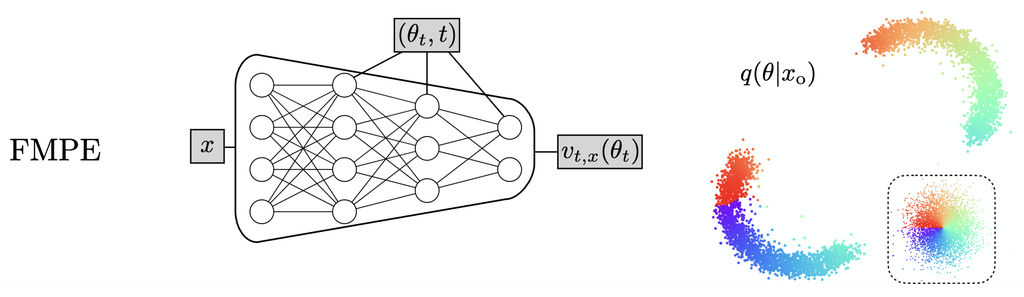

[Dax et al. (2023), Fig. 1, FMPE panel](https://arxiv.org/pdf/2305.17161#page=2)

Flow matching imposes no special architectural constraints on the neural network that parameterizes $v_{t,x}$.

## Score matching

Add noise to the simulated parameters. Learn the noisy posterior score $s_{t,x}(\theta_t)\approx\nabla_{\theta_t}\log p_t(\theta_t\mid x)$ by minimizing

$$\mathcal L_{\mathrm{SM}}(s)
=\mathbb E_{\theta_0,x,t,\theta_t}\!\left[\left\|s_{t,x}(\theta_t)-\nabla_{\theta_t}\log p_t(\theta_t\mid\theta_0)\right\|^2\right].$$

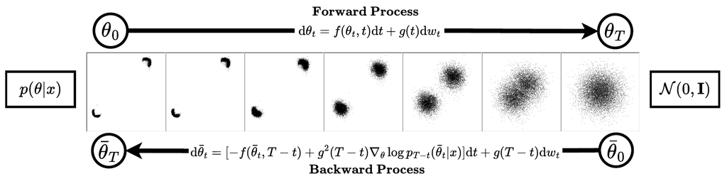

[Sharrock et al. (2024), Fig. 1](https://proceedings.mlr.press/v235/sharrock24a.html)

For fixed $x$, start from Gaussian noise at $t=T$. Use the learned score to run the diffusion back to $t=0$ for an approximate posterior draw.

## Sampling and density evaluation

For fixed $x$, numerically integrate the flow-matching ODE $\dot\theta(t)=v_{t,x}(\theta(t))$.

**Sampling**

Start at $\theta(0)=\theta_0\sim\mathcal N(0,I)$.

Integrate forward from $t=0$ to $1$.

Return $\theta(1)$ as the posterior draw.

**Density evaluation**

Start at $\theta(1)=\theta$.

Integrate backward from $t=1$ to $0$.

$$\begin{aligned}
\log q_\phi(\theta\mid x)
&= \log \mathcal N(\theta(0)\mid 0,I)\\
&\quad - \int_0^1 (\operatorname{div} v_{t,x})(\theta(t))\,dt .
\end{aligned}$$

[Dax et al. (2023), *Flow Matching for Scalable Simulation-Based Inference*, Eqs. (2)–(3)](https://arxiv.org/pdf/2305.17161#page=4)

## Flow matching in the SIR example

Condition on all eight observed maps $x^*$. Start each draw at $\theta_0=\eta\sim\mathcal N(0,I)$ and follow $\dot\theta_t=v_{t,x^*}(\theta_t)$ to $t=1$.

[interactive chart not shown]

0.00

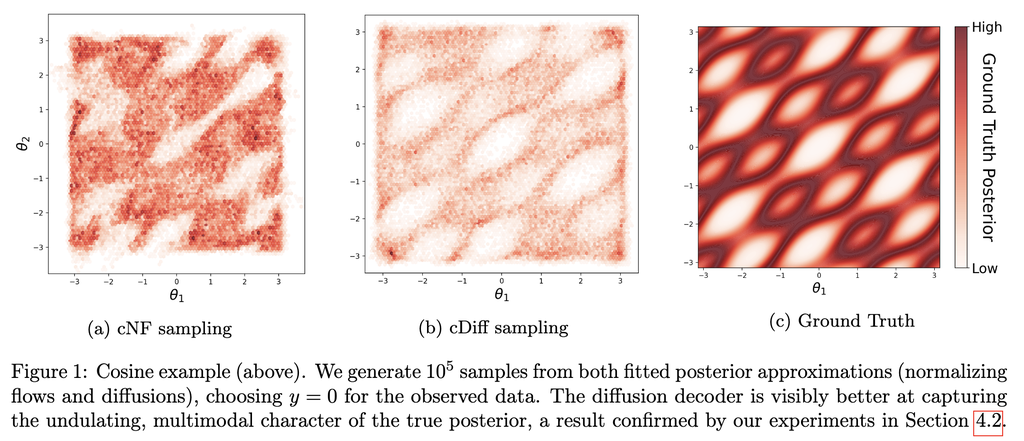

[Chen, Bansal and Scott (2024), Fig. 1](https://arxiv.org/pdf/2410.19105)

## Recent advances

**Compositional score modeling** combines scores from conditionally independent observations to sample a shared posterior. [Geffner et al. (2023)](https://proceedings.mlr.press/v202/geffner23a.html)

**Consistency models** generate a posterior draw in one or a few network evaluations. [Schmitt et al. (2024)](https://proceedings.neurips.cc/paper_files/paper/2024/hash/e58026e2b2929108e1bd24cbfa1c8e4b-Abstract-Conference.html)

**Flow matching calibration** uses a small set of observations with known parameters to correct posterior estimates under simulator misspecification. [Ruhlmann et al. (2026)](https://proceedings.mlr.press/v306/ruhlmann26a.html)

# Research Direction II: Summary Statistics

## Why use summary statistics?

$$x\in\mathcal X\subseteq\mathbb R^n,\qquad S:\mathcal X\to\mathbb R^d$$

- **Dimension reduction.** $d<n$
- **Bias and variance.**

[figure not shown]

Illustrative curves for a fixed simulation budget.

## What makes a good summary?

$$q_\phi(\theta\mid S(x))\approx p(\theta\mid S(x))\approx p(\theta\mid x)$$

- NPE learns the posterior given $S(x)$.
- A good summary preserves the information about $\theta$ needed for inference.
- If $S$ is sufficient, $p(\theta\mid S(x))=p(\theta\mid x)$.

## No summary statistics

### Raw maps + direct NPE

Flatten the three maps into 1,728 inputs and pass them straight to the flow.

[Dax et al. (2023), Fig. 1, NPE architecture](https://arxiv.org/pdf/2305.17161#page=2)

## Hand-picked summaries

Let $X=(X_4,X_8,X_{12})$ be the three infection maps.

### Counts only

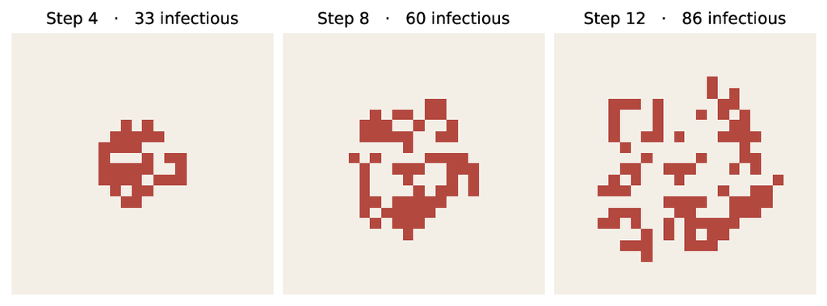

$C_t$ counts infectious cells at visit $t$.

$$\begin{aligned}
S(X) &= (C_4,C_8,C_{12}) \\
&= (33,60,86).
\end{aligned}$$

### Counts + overlaps

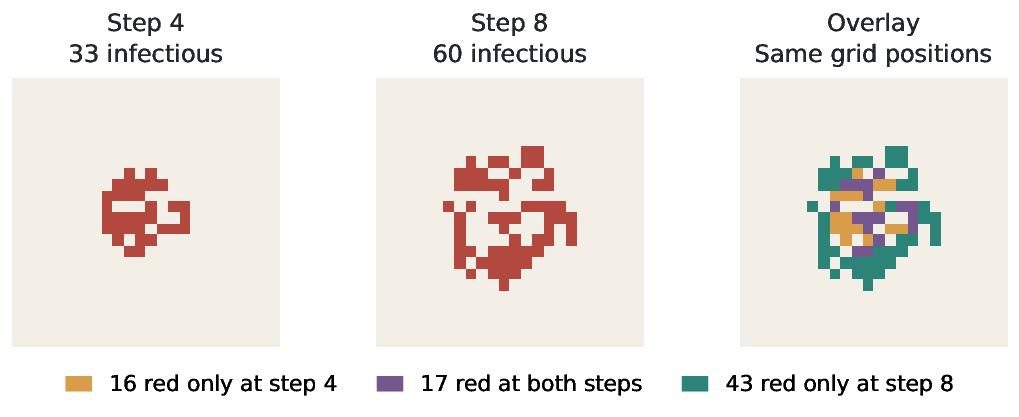

$O_{t,u}$ counts cells infectious at both visits.

$$\begin{aligned}
S(X) &= (C_4,C_8,C_{12},O_{4,8},O_{8,12}) \\
&= (33,60,86,17,25).
\end{aligned}$$

## Learn end to end

### Raw maps + CNN

Train the CNN encoder and the flow together. The CNN learns 16 features from the three maps.

[Dax et al. (2023), Fig. 1, NPE architecture](https://arxiv.org/pdf/2305.17161#page=2)

## Learn separately

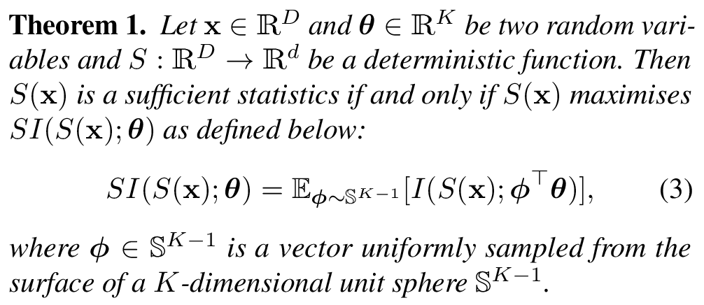

[Chen, Gutmann, and Weller (2023), Theorem 1](https://proceedings.mlr.press/v202/chen23h/chen23h.pdf#page=3)

## SIR example

Three visits with immediate onset · Closer to 50% (chance) is better

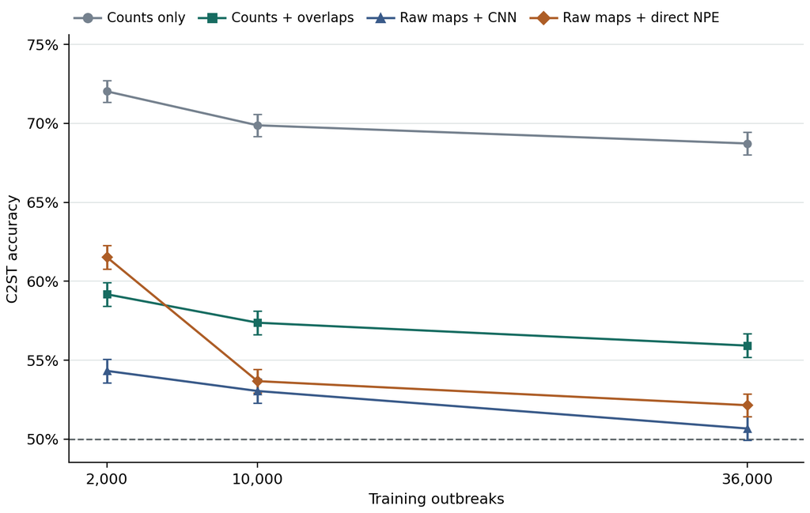

**Counts only**3 counts

**Counts + overlaps**5 summary statistics

**CNN**16 learned features

**Direct NPE**1,728 raw entries

# Research Direction III: Model Misspecification

## When the truth lies outside the model

[figure not shown]

$$\varepsilon = \inf_{\theta\in\Theta}D\!\left[p_0(x):p(x\mid\theta)\right]>0$$

## Introducing misspecification to SIR

**Assumed simulator**

S⟶I⟶R

=≠

**Data-generating process**

S⟶Eeight steps⟶I⟶R

Simulated states

[interactive chart not shown]

Last simulated visit

[interactive chart not shown]

Step 8

One person per cellSusceptibleExposedInfectiousRecovered

## The effect of misspecification

Parameter range Zoomed Full square

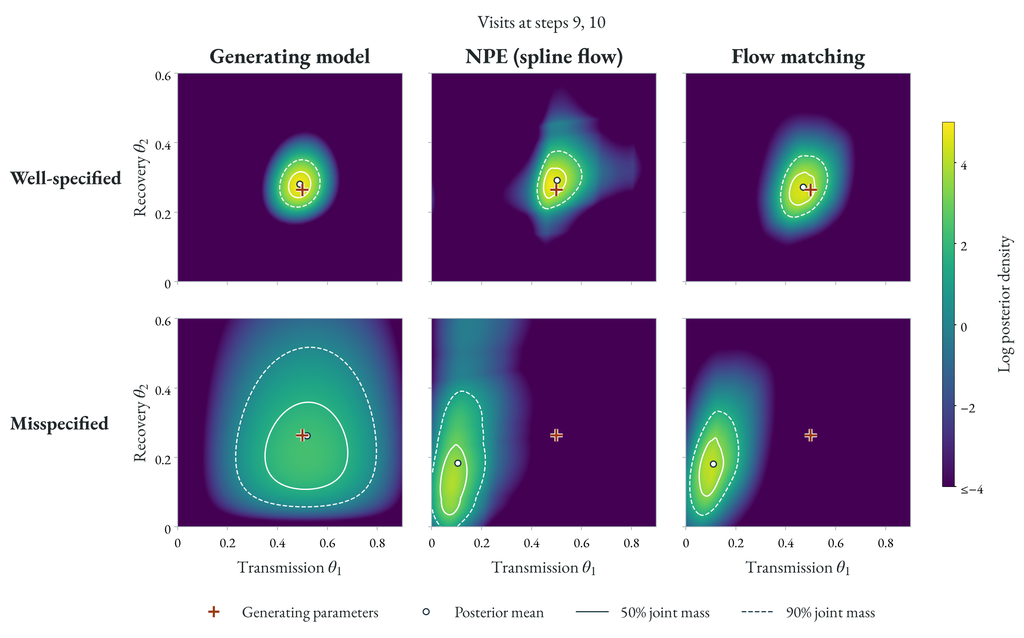

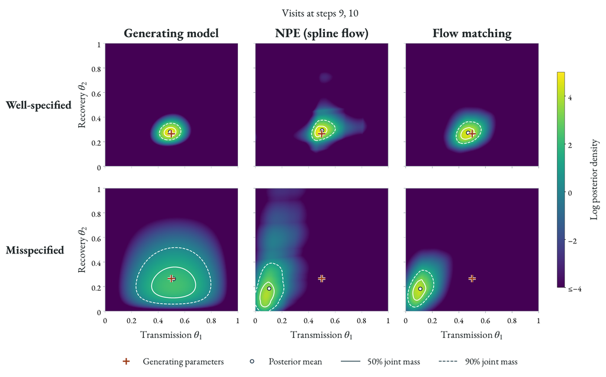

## Coverage under delayed onset

For each delay, how often does the fitted region contain the transmission and recovery rates that generated the step-12 map?

[figure not shown]

## Dealing with model misspecification

**Posterior ensembles** average the posterior densities from independently trained networks. [Cannon et al. (2022)](https://arxiv.org/pdf/2209.01845#page=6)

**Regularized summaries** retain information about the parameters while penalizing differences between simulated and observed summaries. [Huang et al. (2023)](https://proceedings.neurips.cc/paper_files/paper/2023/file/16c5b4102a6b6eb061e502ce6736ad8a-Paper-Conference.pdf)

**Discrepancy models** specify how an observation can differ from the simulator output. [Ward et al. (2022)](https://papers.neurips.cc/paper_files/paper/2022/hash/db0eac6747e3631eb91095cd76065611-Abstract-Conference.html)

Does **posterior contraction** still occur under model misspecification, and if so, what does it look like? [Gelman and Shalizi (2013)](https://sites.stat.columbia.edu/gelman/research/published/philosophy.pdf)

# New advances

## Research Direction IV: Scalable and flexible SBI

**All-in-one SBI** trains one network to sample parameters given data or data given parameters. [Gloeckler et al. (2024)](https://proceedings.mlr.press/v235/gloeckler24a.html)

**NPE-PFN** uses simulated $(\theta,x)$ pairs as context for a pretrained tabular model to estimate the posterior at $x^*$. [Vetter et al. (2025)](https://papers.nips.cc/paper_files/paper/2025/hash/770cabd044c4eacb6dc5924d9a686dce-Abstract-Conference.html)

## Research Direction V: Simulator transparency

Using the internal states $z$ of the simulator to improve inference

**Mining gold** uses the joint score of $(x,z)$ to train a likelihood estimator. [Brehmer et al. (2020)](https://pmc.ncbi.nlm.nih.gov/articles/PMC7071889/)

**Inference compilation** learns from simulated paths to propose hidden states consistent with the observation. [Le et al. (2017)](https://proceedings.mlr.press/v54/le17a.html)

# Thank you

Special thanks to Yichen Ji and Prof. Ricardo Baptista